# Определение стоимости автомобилей

Сервис по продаже автомобилей с пробегом разрабатывает приложение для привлечения новых клиентов. В нём можно быстро узнать рыночную стоимость своего автомобиля. В вашем распоряжении исторические данные: технические характеристики, комплектации и цены автомобилей. Вам нужно построить модель для определения стоимости.

Заказчику важны:

- качество предсказания;
- скорость предсказания;
- время обучения.

# Импорт библиотек и объявление констант

```python
from IPython.core.display import display, HTML
display(HTML("<style>.container { width:75% !important; }</style>"))
```

```python
import warnings
warnings.simplefilter(action='ignore', category=Warning)

import time as tm

import re

!pip install numba --upgrade -q

!pip install scipy --upgrade -q
from scipy import stats

!pip install numpy==1.23 -q
import numpy as np

!pip install pandas --upgrade -q
import pandas as pd

!pip install matplotlib --upgrade -q
import matplotlib.pyplot as plt

!pip install skimpy -q
from skimpy import skim

!pip install phik -q
import phik

!pip install seaborn --upgrade -q
import seaborn as sns

!pip install scikit-learn --upgrade -q
from sklearn.preprocessing import OneHotEncoder, OrdinalEncoder, StandardScaler, MinMaxScaler, RobustScaler
from sklearn.pipeline import Pipeline
from sklearn.compose import ColumnTransformer
from sklearn.model_selection import train_test_split, RandomizedSearchCV, GridSearchCV
from sklearn.metrics import root_mean_squared_error as rmse
from sklearn.tree import DecisionTreeRegressor
from sklearn.linear_model import LinearRegression, Ridge
from sklearn.ensemble import RandomForestRegressor
from sklearn.dummy import DummyRegressor

!pip install LightGBM -q
from lightgbm import LGBMRegressor

!pip install catboost -q
from catboost import CatBoostRegressor, cv

RANDOM_STATE = 17
alpha = 0.01
test_size = 0.25
```

# Функции для проекта

```python
def unique_identifier(df):
    print('#########################')
    for column_name in df.select_dtypes(include='object').columns:
            print(f'unique values in col "{column_name}": {df[column_name].unique()}')
            print('#########################')
```

```python
def bootstrap_mean_dist(df, col, num_subsamples, n):

    state = np.random.RandomState(RANDOM_STATE)
    values = []

    for i in range (num_subsamples):

        subsamp = df[col].sample(n=n, replace=False, random_state=state)
        values.append(subsamp.mean())

    return values
```

```python
def num_cols_bootstrap_stattest():

    cars_na = cars[cars.isna().any(axis=1)]

    for column in cars.select_dtypes(include=['int64', 'float64']).columns:

        not_na = np.array(bootstrap_mean_dist(cars.dropna(axis=0), column, 1000, 10000))
        na = np.array(bootstrap_mean_dist(cars_na, column, 1000, 10000))

        result = stats.ttest_ind(not_na, na, alternative='two-sided')

        if result.pvalue < alpha:
            print('Похоже, статистически значимая разница между распределениями средних признака "{}" есть'.format(column))
        else:
            print('Похоже, статистически значимой разницы между распределениями средних признака "{}" нет'.format(column))
```

```python
def num_cols_stattest_ind(samp_1, samp_2):

    for column in samp_1.select_dtypes(include=['int64', 'float64']).columns:

        result = stats.ttest_ind(samp_1[column], samp_2[column], alternative='two-sided')

        if result.pvalue < alpha:
            print('Похоже, статистически значимая разница между распределениями признака "{}" есть'.format(column))
        else:
            print('Похоже, статистически значимой разницы между распределениями средних признака "{}" нет'.format(column))
```

```python
def residuals_analysis_plotter(y_true, y_pred, figsize=(15, 5), xlabel='target_feature', mean_text_x_coef_degree=5, mean_text_y_coef=2, bins=50, suptitle=None, scatter_grid=False):

    residuals = y_true - y_pred

    fig, ax = plt.subplots(1, 2, figsize=figsize)

    ax[0].hist(residuals, bins=bins, color='silver', alpha=0.8)
    ax[0].set_title('распределение остатков (ошибок) модели')
    ax[0].set_xlabel('errors', size=13)
    ax[0].set_ylabel('count', size=13)
    ax[0].grid()

    ax[0].axvline(residuals.mean(), color='C3', linestyle='dashed', linewidth=2.15)
    ax[0].text(x=residuals.mean() + 2**mean_text_x_coef_degree, y=ax[0].get_yticks().max() / mean_text_y_coef, s='Остаточное среднее: {:.2f}'.format(residuals.mean()), size=10)

    ax[1].scatter(y_pred, residuals)

    ax[1].set_title('дисперсия остатков (ошибок) модели')
    ax[1].set_xlabel('{}'.format(str(xlabel)), size=13)
    ax[1].set_ylabel('цена ошибки (error)', size=13)

    if scatter_grid == True:
        ax[1].grid()
    else:
        pass

    if suptitle != None:
        fig.suptitle(suptitle, fontsize=15)
    else:
        pass

    plt.show()
```

```python
def rel_prioritized_inversed_neg_scoring(df_with_ordered_cols, competitors, exclude_cols=None):

    df = df_with_ordered_cols.copy()

    if exclude_cols == None:
        sup_df = df
    else:
        sup_df = df.drop(exclude_cols, axis=1)

    degree = len(sup_df.select_dtypes(include=['int64', 'float64']).columns)

    for column in sup_df.select_dtypes(include=['int64', 'float64']).columns:

        score_name = '{}_score^{}'.format(column, degree)

        new_df = sup_df[[competitors, column]].rename(columns={column: score_name})

        new_df[score_name] = new_df[score_name] + 1

        new_df[score_name] = round(((-new_df[score_name] + new_df[score_name].max()) / (new_df[score_name].max() - new_df[score_name].min())) * np.exp(degree), 2)

        degree -= 1

        df = df.merge(new_df, on=competitors)

    total_score = df.iloc[:, -len(sup_df.select_dtypes(include=['int64', 'float64']).columns):].sum(axis=1)

    df['score_total'] = total_score

    df = df.sort_values(by='score_total', ascending=False).reset_index(drop=True)

    return df
```

## Подготовка данных

### загрузка данных

Загружаем датасет и смотрим, с чем нам придется работать. Сразу запарсим даты.

```python
cars = pd.read_csv('autos.csv', parse_dates=['DateCrawled', 'DateCreated', 'LastSeen'])
cars_shape_raw = cars.shape

display(cars.sample(5))
print('#############################')
display(cars.info())
print('#############################')
print('Размер датасета: {}'.format(cars_shape_raw))
```

|  | DateCrawled | Price | VehicleType | RegistrationYear | Gearbox | Power | Model | Kilometer | RegistrationMonth | FuelType | Brand | Repaired | DateCreated | NumberOfPictures | PostalCode | LastSeen |
| --- | --- | --- | --- | --- | --- | --- | --- | --- | --- | --- | --- | --- | --- | --- | --- | --- |
| 282306 | 2016-03-26 09:52:28 | 4049 | wagon | 2006 | manual | 140 | signum | 150000 | 9 | petrol | opel | no | 2016-03-26 | 0 | 97247 | 2016-04-01 22:46:03 |
| 5514 | 2016-03-24 10:49:17 | 4199 | convertible | 2005 | manual | 109 | 2_reihe | 150000 | 6 | petrol | peugeot | no | 2016-03-24 | 0 | 52249 | 2016-04-07 01:15:45 |
| 293843 | 2016-03-27 21:55:40 | 1400 | NaN | 2008 | manual | 80 | fiesta | 90000 | 8 | petrol | ford | yes | 2016-03-27 | 0 | 71720 | 2016-03-29 12:18:32 |
| 131266 | 2016-03-16 09:36:55 | 1800 | wagon | 1998 | auto | 224 | e_klasse | 150000 | 7 | petrol | mercedes_benz | no | 2016-03-16 | 0 | 4435 | 2016-03-20 08:16:35 |
| 6304 | 2016-03-23 14:41:54 | 6700 | sedan | 2005 | manual | 177 | 5er | 150000 | 5 | petrol | bmw | no | 2016-03-23 | 0 | 21255 | 2016-03-23 14:41:54 |

```
#############################
<class 'pandas.core.frame.DataFrame'>
RangeIndex: 354369 entries, 0 to 354368
Data columns (total 16 columns):
 #   Column             Non-Null Count   Dtype
---  ------             --------------   -----
 0   DateCrawled        354369 non-null  datetime64[ns]
 1   Price              354369 non-null  int64
 2   VehicleType        316879 non-null  object
 3   RegistrationYear   354369 non-null  int64
 4   Gearbox            334536 non-null  object
 5   Power              354369 non-null  int64
 6   Model              334664 non-null  object
 7   Kilometer          354369 non-null  int64
 8   RegistrationMonth  354369 non-null  int64
 9   FuelType           321474 non-null  object
 10  Brand              354369 non-null  object
 11  Repaired           283215 non-null  object
 12  DateCreated        354369 non-null  datetime64[ns]
 13  NumberOfPictures   354369 non-null  int64
 14  PostalCode         354369 non-null  int64
 15  LastSeen           354369 non-null  datetime64[ns]
dtypes: datetime64[ns](3), int64(7), object(6)
memory usage: 43.3+ MB
```

```
None
```

```
#############################
Размер датасета: (354369, 16)
```

Всего в датасете около 350000 записей и 16 полей. В некоторых столбцах есть пропуски. Все данные во всех столбцах приведены к нужным типам. Далее посмотрим чуть более детальную статистику.

### Осмотр датасета

```python
skim(cars)
```

```
╭──────────────────────────────────────────────── skimpy summary ─────────────────────────────────────────────────╮
│          Data Summary                Data Types                                                                 │
│ ┏━━━━━━━━━━━━━━━━━━━┳━━━━━━━━┓ ┏━━━━━━━━━━━━━┳━━━━━━━┓                                                          │
│ ┃ dataframe         ┃ Values ┃ ┃ Column Type ┃ Count ┃                                                          │
│ ┡━━━━━━━━━━━━━━━━━━━╇━━━━━━━━┩ ┡━━━━━━━━━━━━━╇━━━━━━━┩                                                          │
│ │ Number of rows    │ 354369 │ │ int64       │ 7     │                                                          │
│ │ Number of columns │ 16     │ │ string      │ 6     │                                                          │
│ └───────────────────┴────────┘ │ datetime64  │ 3     │                                                          │
│                                └─────────────┴───────┘                                                          │
│                                                     number                                                      │
│ ┏━━━━━━━━━━━━━━━━━━━━━┳━━━━━┳━━━━━━━┳━━━━━━━━━┳━━━━━━━━┳━━━━━━━┳━━━━━━━━━┳━━━━━━━━┳━━━━━━━━┳━━━━━━━━┳━━━━━━━━┓  │
│ ┃ column_name         ┃ NA  ┃ NA %  ┃ mean    ┃ sd     ┃ p0    ┃ p25     ┃ p50    ┃ p75    ┃ p100   ┃ hist   ┃  │
│ ┡━━━━━━━━━━━━━━━━━━━━━╇━━━━━╇━━━━━━━╇━━━━━━━━━╇━━━━━━━━╇━━━━━━━╇━━━━━━━━━╇━━━━━━━━╇━━━━━━━━╇━━━━━━━━╇━━━━━━━━┩  │
│ │ Price               │   0 │     0 │    4417 │   4514 │     0 │    1050 │   2700 │   6400 │  20000 │ ▇▃▂▁▁  │  │
│ │ RegistrationYear    │   0 │     0 │    2004 │  90.23 │  1000 │    1999 │   2003 │   2008 │   9999 │   ▇    │  │
│ │ Power               │   0 │     0 │   110.1 │  189.9 │     0 │      69 │    105 │    143 │  20000 │   ▇    │  │
│ │ Kilometer           │   0 │     0 │  128200 │  37910 │  5000 │  125000 │ 150000 │ 150000 │ 150000 │  ▁▁▁▁▇ │  │
│ │ RegistrationMonth   │   0 │     0 │   5.715 │  3.726 │     0 │       3 │      6 │      9 │     12 │ ▆▆▆▆▅▇ │  │
│ │ NumberOfPictures    │   0 │     0 │       0 │      0 │     0 │       0 │      0 │      0 │      0 │     ▇  │  │
│ │ PostalCode          │   0 │     0 │   50510 │  25780 │  1067 │   30160 │  49410 │  71080 │ 100000 │ ▅▇▇▇▅▅ │  │
│ └─────────────────────┴─────┴───────┴─────────┴────────┴───────┴─────────┴────────┴────────┴────────┴────────┘  │
│                                                    datetime                                                     │
│ ┏━━━━━━━━━━━━━━━━━━┳━━━━━━┳━━━━━━━━━┳━━━━━━━━━━━━━━━━━━━━━━━━━━━━┳━━━━━━━━━━━━━━━━━━━━━━━━━━━━┳━━━━━━━━━━━━━━┓  │
│ ┃ column_name      ┃ NA   ┃ NA %    ┃ first                      ┃ last                       ┃ frequency    ┃  │
│ ┡━━━━━━━━━━━━━━━━━━╇━━━━━━╇━━━━━━━━━╇━━━━━━━━━━━━━━━━━━━━━━━━━━━━╇━━━━━━━━━━━━━━━━━━━━━━━━━━━━╇━━━━━━━━━━━━━━┩  │
│ │ DateCrawled      │    0 │       0 │    2016-03-05 14:06:22     │    2016-04-07 14:36:58     │ None         │  │
│ │ DateCreated      │    0 │       0 │         2014-03-10         │         2016-04-07         │ None         │  │
│ │ LastSeen         │    0 │       0 │    2016-03-05 14:15:08     │    2016-04-07 14:58:51     │ None         │  │
│ └──────────────────┴──────┴─────────┴────────────────────────────┴────────────────────────────┴──────────────┘  │
│                                                     string                                                      │
│ ┏━━━━━━━━━━━━━━━━━━━━━━━━━┳━━━━━━━━━━━━━━┳━━━━━━━━━━━━━┳━━━━━━━━━━━━━━━━━━━━━━━━━━━━┳━━━━━━━━━━━━━━━━━━━━━━━━┓  │
│ ┃ column_name             ┃ NA           ┃ NA %        ┃ words per row              ┃ total words            ┃  │
│ ┡━━━━━━━━━━━━━━━━━━━━━━━━━╇━━━━━━━━━━━━━━╇━━━━━━━━━━━━━╇━━━━━━━━━━━━━━━━━━━━━━━━━━━━╇━━━━━━━━━━━━━━━━━━━━━━━━┩  │
│ │ VehicleType             │        37490 │       10.58 │                       0.89 │                 316879 │  │
│ │ Gearbox                 │        19833 │         5.6 │                       0.94 │                 334536 │  │
│ │ Model                   │        19705 │        5.56 │                       0.94 │                 334664 │  │
│ │ FuelType                │        32895 │        9.28 │                       0.91 │                 321474 │  │
│ │ Brand                   │            0 │           0 │                          1 │                 354369 │  │
│ │ Repaired                │        71154 │       20.08 │                        0.8 │                 283215 │  │
│ └─────────────────────────┴──────────────┴─────────────┴────────────────────────────┴────────────────────────┘  │
╰────────────────────────────────────────────────────── End ──────────────────────────────────────────────────────╯
```

1. все пропуски содержатся в категориальных столбцах. В поле 'Repaired' больше всего пропусков - они составляют порядка 20% всего датасета. Разберемся с ними далее.
2. В датасете присутствуют автомобили с ценой 0: скорее всего, это аномалия. Оценим масштаб и разберемся с этим далее.
3. Минимальное значение в поле 'RegistrationYear' равно 1000, а максимальное - 9999. С этим тоже разберемся далее.
4. Минимальное значение в поле 'Power' равно 0, а максимальное - 20000. Это тоже аномалии.
5. В поле 'Kilometer' на первый взгляд все в порядке.
6. Поле 'NumberOfPictures', похоже, содержит одно единственное значение - 0. Его можно удалить.
7. С почтовыми индексами всё вроде в порядке.
8. Похоже, данные собирались в течение одного месяца в 2016 году: с 5 марта по 7 апреля.
9. Даты создания объявлений в порядке.
10. Единственный столбец с категориальными данными, который не содержит пропусков - 'Brand'

Посмотрим на количество уникальных значений категориальных признаков.

```python
print('уникальные значения в категориальных столбцах (пропуски не учитываются):')
for col in cars.select_dtypes(include='object').columns:
    print('______________________________\n',
          '"{}" has {} unique values.'.format(col, cars[col].nunique())
         )
```

```
уникальные значения в категориальных столбцах (пропуски не учитываются):
______________________________
 "VehicleType" has 8 unique values.
______________________________
 "Gearbox" has 2 unique values.
______________________________
 "Model" has 250 unique values.
______________________________
 "FuelType" has 7 unique values.
______________________________
 "Brand" has 40 unique values.
______________________________
 "Repaired" has 2 unique values.
```

Бегло оценим распределения числовых признаков.

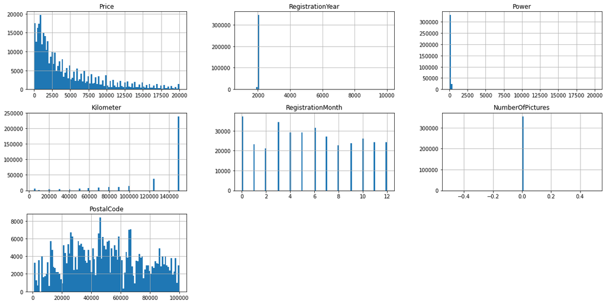

```python
cars.select_dtypes(exclude=['object', 'datetime']).hist(bins=100, figsize=(20, 10))
plt.show()
```

В целом, распределения числовых признаков выглядят нормально (не учитывая растяжения графиков по оси Ox для признаков 'RegistrationYear' и 'Power'). Вот их особенности:

1. Видим длинный правый хвост распределения цены автомобилей; судя по всему, около самого нуля очень много небольших значений. Берем этот факт на карандашик.
2. Большинство значений года регистрации распределено вокруг 2000, так, по идее, и должно быть.
3. Большинство значений мощности автомобилей, похоже, находится до 1000. Это нормально.
4. Подавляющее большинство значений в поле с пробегом находится на отметке в 150000. По всей видимости, сервис позволяет выбрать пробег только до 150000 включительно, и большинство продавцов б/у машин с пробегом равным или больше 150 тыс. просто поставили максимально возможный пробег.
5. Месяцы регистрации в принципе распределены более-менее равномерно. Тем не менее, видим 13 значений вместо 12. Есть два варианта: значение 0 может говорить об отсутствии данных, или, что наиболее вероятно, под 0 подразумевается декабрь предыдущего года. Согласно статистике, по миру, в т.ч. и в Европе, наиболее популярными для покупки и регистрации автомобилей является сезон весна-лето (видим всплеск активности регистрации авто в марте, который начинает окончательно падать к июлю), а также, наиболее активный в сравнении с остальными декабрь месяц. Учитывая тот факт, что на графике декабрь находится чуть ли не самым 'спокойным' месяцем, хотя должен быть первым с огромным отрывом (в декабре в среднем регистрируют авто в 2-2.5 раза чаще), пожалуй, будем считать значение 0 декабрем предыдущего года.
6. Со столбцом 'NumberOfPictures' всё понятно - скорее всего произошел сбой при выгрузке данных. Этот столбец подлежит удалению, т.к. полностью неинформативен.
7. Почтовые индексы распределены более-менее равномерно, как и должны.

С осмотром покончили, приступаем к предобработке.

### Предобработка данных

Начнем со стандартизации наименований столбцов и данных, дубликатов и пропусков, затем перейдем к числовым данным и дате со временем.

#### Неявные дубликаты. Стандартизация наименований столбцов и значений категориальных признаков

Сначала приведем названия столбцов к змеиному регистру.

```python
cars.columns = [re.sub(r'(?<!^)(?=[A-Z])', '_', i).lower() for i in cars.columns]

print(cars.columns)
```

```
Index(['date_crawled', 'price', 'vehicle_type', 'registration_year', 'gearbox',
       'power', 'model', 'kilometer', 'registration_month', 'fuel_type',
       'brand', 'repaired', 'date_created', 'number_of_pictures',
       'postal_code', 'last_seen'],
      dtype='object')
```

Теперь осмотрим значения категориальных признаков на наличие неявных дубликатов.

```python
unique_identifier(cars)
```

```
#########################
unique values in col "vehicle_type": [nan 'coupe' 'suv' 'small' 'sedan' 'convertible' 'bus' 'wagon' 'other']
#########################
unique values in col "gearbox": ['manual' 'auto' nan]
#########################
unique values in col "model": ['golf' nan 'grand' 'fabia' '3er' '2_reihe' 'other' 'c_max' '3_reihe'
 'passat' 'navara' 'ka' 'polo' 'twingo' 'a_klasse' 'scirocco' '5er'
 'meriva' 'arosa' 'c4' 'civic' 'transporter' 'punto' 'e_klasse' 'clio'
 'kadett' 'kangoo' 'corsa' 'one' 'fortwo' '1er' 'b_klasse' 'signum'
 'astra' 'a8' 'jetta' 'fiesta' 'c_klasse' 'micra' 'vito' 'sprinter' '156'
 'escort' 'forester' 'xc_reihe' 'scenic' 'a4' 'a1' 'insignia' 'combo'
 'focus' 'tt' 'a6' 'jazz' 'omega' 'slk' '7er' '80' '147' '100' 'z_reihe'
 'sportage' 'sorento' 'v40' 'ibiza' 'mustang' 'eos' 'touran' 'getz' 'a3'
 'almera' 'megane' 'lupo' 'r19' 'zafira' 'caddy' 'mondeo' 'cordoba' 'colt'
 'impreza' 'vectra' 'berlingo' 'tiguan' 'i_reihe' 'espace' 'sharan'
 '6_reihe' 'panda' 'up' 'seicento' 'ceed' '5_reihe' 'yeti' 'octavia' 'mii'
 'rx_reihe' '6er' 'modus' 'fox' 'matiz' 'beetle' 'c1' 'rio' 'touareg'
 'logan' 'spider' 'cuore' 's_max' 'a2' 'galaxy' 'c3' 'viano' 's_klasse'
 '1_reihe' 'avensis' 'roomster' 'sl' 'kaefer' 'santa' 'cooper' 'leon'
 '4_reihe' 'a5' '500' 'laguna' 'ptcruiser' 'clk' 'primera' 'x_reihe'
 'exeo' '159' 'transit' 'juke' 'qashqai' 'carisma' 'accord' 'corolla'
 'lanos' 'phaeton' 'verso' 'swift' 'rav' 'picanto' 'boxster' 'kalos'
 'superb' 'stilo' 'alhambra' 'mx_reihe' 'roadster' 'ypsilon' 'cayenne'
 'galant' 'justy' '90' 'sirion' 'crossfire' 'agila' 'duster' 'cr_reihe'
 'v50' 'c_reihe' 'v_klasse' 'm_klasse' 'yaris' 'c5' 'aygo' 'cc' 'carnival'
 'fusion' '911' 'bora' 'forfour' 'm_reihe' 'cl' 'tigra' '300c' 'spark'
 'v70' 'kuga' 'x_type' 'ducato' 's_type' 'x_trail' 'toledo' 'altea'
 'voyager' 'calibra' 'bravo' 'antara' 'tucson' 'citigo' 'jimny' 'wrangler'
 'lybra' 'q7' 'lancer' 'captiva' 'c2' 'discovery' 'freelander' 'sandero'
 'note' '900' 'cherokee' 'clubman' 'samara' 'defender' '601' 'cx_reihe'
 'legacy' 'pajero' 'auris' 'niva' 's60' 'nubira' 'vivaro' 'g_klasse'
 'lodgy' '850' 'range_rover' 'q3' 'serie_2' 'glk' 'charade' 'croma'
 'outlander' 'doblo' 'musa' 'move' '9000' 'v60' '145' 'aveo' '200' 'b_max'
 'range_rover_sport' 'terios' 'rangerover' 'q5' 'range_rover_evoque'
 'materia' 'delta' 'gl' 'kalina' 'amarok' 'elefantino' 'i3' 'kappa'
 'serie_3' 'serie_1']
#########################
unique values in col "fuel_type": ['petrol' 'gasoline' nan 'lpg' 'other' 'hybrid' 'cng' 'electric']
#########################
unique values in col "brand": ['volkswagen' 'audi' 'jeep' 'skoda' 'bmw' 'peugeot' 'ford' 'mazda'
 'nissan' 'renault' 'mercedes_benz' 'opel' 'seat' 'citroen' 'honda' 'fiat'
 'mini' 'smart' 'hyundai' 'sonstige_autos' 'alfa_romeo' 'subaru' 'volvo'
 'mitsubishi' 'kia' 'suzuki' 'lancia' 'toyota' 'chevrolet' 'dacia'
 'daihatsu' 'trabant' 'saab' 'chrysler' 'jaguar' 'daewoo' 'porsche'
 'rover' 'land_rover' 'lada']
#########################
unique values in col "repaired": [nan 'yes' 'no']
#########################
```

Категориальные значения уже приведены к змеиному регистру; при беглом осмотре есть несколько опечаток и неявных дубликатов:

1. 'petrol' и 'gasoline' в столбце 'fuel_type'
2. 'rangerover' и 'range_rover' в столбце 'model'
3. 'rover' и 'land_rover' в столбце 'brand'

Исправим их.

```python
cars.loc[cars['fuel_type'] == 'petrol', 'fuel_type'] = 'gasoline'
cars.loc[cars['model'] == 'rangerover', 'model'] = 'range_rover'
cars.loc[cars['brand'] == 'rover', 'brand'] = 'land_rover'
```

```python
display(cars.query('fuel_type == "petrol" | model == "rangerover" | brand == "rover"'))
```

|  | date_crawled | price | vehicle_type | registration_year | gearbox | power | model | kilometer | registration_month | fuel_type | brand | repaired | date_created | number_of_pictures | postal_code | last_seen |
| --- | --- | --- | --- | --- | --- | --- | --- | --- | --- | --- | --- | --- | --- | --- | --- | --- |

Теперь проверим датасет на наличие явных дубликатов.

#### Обработка явных дубликатов

Найдем число явных дубликатов в нашем датасете.

```python
print('amount of full duplicates in the datset: {}'.format(cars.duplicated().sum()))
```

```
amount of full duplicates in the datset: 4
```

Их всего 4 штуки, так что можно смело удалять.

```python
cars = cars.drop_duplicates()

print(len(cars))
```

```
354365
```

Идем дальше.

#### Работа с пропусками

С пропусками все сложнее. в одном из столбцов количество пропусков более 20% от всего датасета. Посмотрим, сколько данных у нас останется после удаления.

```python
print('Процент оставшихся данных после удаления всех пропусков из датасета: {}%'.format(round(len(cars.dropna(axis=0)) / len(cars) * 100, 2)))
print('число удаляемых строк: {}'.format(len(cars) - len(cars.dropna())))
```

```
Процент оставшихся данных после удаления всех пропусков из датасета: 69.37%
число удаляемых строк: 108555
```

Внушительное число, более 30% всего датасета будет удалено, если мы избавимся от всех пропусков во всех столбцах. Тем не менее, данных у нас довольно много, поэтому, вероятно, их можно и удалить без зазрения совести, если это не скажется на данных и их распределениях. Попробуем косвенно оценить изменения, например, по количественным признакам, в частности таргету, проведя статистический тест для бутстреп-выборок ожидаемых значений числовых признаков для объектов, где есть пропуски, и для тех, где их нет.

```python
num_cols_bootstrap_stattest()
```

```
Похоже, статистически значимая разница между распределениями средних признака "price" есть
Похоже, статистически значимая разница между распределениями средних признака "registration_year" есть
Похоже, статистически значимая разница между распределениями средних признака "power" есть
Похоже, статистически значимая разница между распределениями средних признака "kilometer" есть
Похоже, статистически значимая разница между распределениями средних признака "registration_month" есть
Похоже, статистически значимой разницы между распределениями средних признака "number_of_pictures" нет
Похоже, статистически значимая разница между распределениями средних признака "postal_code" есть
```

По всей видимости, такое большое число объектов просто взять и выкинуть мы не можем, это ожидаемо повлияет на модель наших данных. Однако мы можем попробовать удалить только те объекты, где во всех возможных колонках наблюдаются пропуски: такие объекты, учитывая количество признаков с пропусками, всё равно будут малоинформативны и только засорят модель. Посмотрим, как это скажется на наших данных.

```python
cars_1 = cars.dropna(axis=0, how='all', subset=['vehicle_type', 'gearbox', 'model', 'fuel_type', 'repaired']).copy()

print('remaining data percentage after deleting all of the omissions by the full subset from the dataset: {}%'.format(round(len(cars.dropna(axis=0, how='all', subset=['vehicle_type', 'gearbox', 'model', 'fuel_type', 'repaired'])) / len(cars) * 100, 2)))
print('amount of the deleted rows: {}'.format(len(cars) - len(cars.dropna(axis=0, how='all', subset=['vehicle_type', 'gearbox', 'model', 'fuel_type', 'repaired']))))
```

```
remaining data percentage after deleting all of the omissions by the full subset from the dataset: 99.37%
amount of the deleted rows: 2237
```

```python
num_cols_stattest_ind(cars, cars_1)
```

```
Похоже, статистически значимой разницы между распределениями средних признака "price" нет
Похоже, статистически значимой разницы между распределениями средних признака "registration_year" нет
Похоже, статистически значимой разницы между распределениями средних признака "power" нет
Похоже, статистически значимой разницы между распределениями средних признака "kilometer" нет
Похоже, статистически значимая разница между распределениями признака "registration_month" есть
Похоже, статистически значимой разницы между распределениями средних признака "number_of_pictures" нет
Похоже, статистически значимой разницы между распределениями средних признака "postal_code" нет
```

Таких пропусков менее процента в наших данных, а распределения признаков (кроме месяца) ощутимо не изменятся. Можем смело удалять такие объекты.

```python
cars = cars_1.copy()
```

Теперь с пропусками надо что-то сделать. По порядку:

1. В датасете всего два типа коробки передач: механическая и автоматическая. Помимо авто и механики существует ещё множество видов, например, вариатор или полуавтомат. Наиболее вероятно, к одному из них и относятся пропущенные значения, поэтому назначим на место пропусков значение 'other'. То же относится и к типам кузовов.
2. Признаки 'model' и 'fuel_type' содержат категории 'other', но приписать к ним пропущенные значения мы не можем: достоверно неизвестно, действительно ли та или иная модель или тип топлива принадлежат к категории 'other', тем более что одни и те же модели, но разных серий, могут иметь разные типы топлива. Отнеся такие случаи к категории 'other', мы внесем отсебятину в данные и только запутаем модель. Поэтому определим для пропусков значение 'не установлено' ('unspecified').
3. Пропускам в столбце 'repaired' тоже присвоим значение 'не установлено', потому что это, собственно, так и есть, да и придумать что-то другое здесь сложно.

```python
cars['gearbox'] = cars['gearbox'].fillna('other')
cars['vehicle_type'] = cars['vehicle_type'].fillna('other')

cars['model'] = cars['model'].fillna('unspecified')
cars['fuel_type'] = cars['fuel_type'].fillna('unspecified')

cars['repaired'] = cars['repaired'].fillna('unspecified')
```

#### Удаление заведомо неинформативных признаков

На этом этапе, пожалуй, удалим неинформативные признаки. Даты последней активности и сбора информации нам не пригодятся, поскольку являются метаданными и в определении непосредственной стоимости авто участвовать не могут. Также удалим признак 'number_of_pictures', по причине, обозначенной ранее. P.S. заранее на всякий случай сохраним дату сбора информации в отдельную переменную; она может пригодиться в расчетах.

```python
date_crawled = cars['date_crawled']

try:
    cars = cars.drop(['date_crawled', 'last_seen', 'number_of_pictures'], axis=1)
except:
    pass
```

#### Работа с аномальными значениями

Теперь приступим к работе с аномальными значениями количественных признаков и дат. Начнем, соответственно, с первых.

##### Количественные признаки

Еще раз построим гистограммы для числовых данных.

```python
num_values = ['euros', 'horsepower', 'kilometers', 'codes']
```

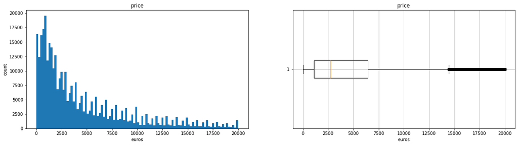

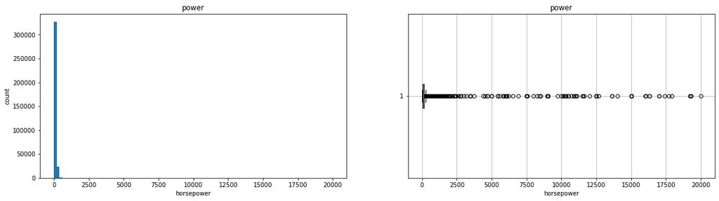

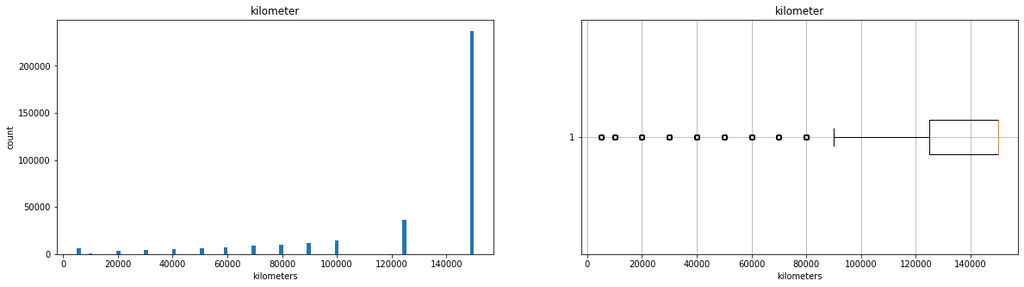

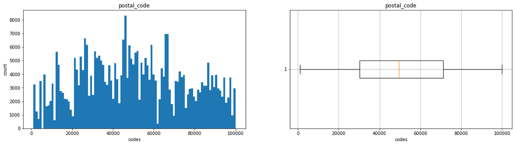

```python
for i, j in zip(cars.drop(['registration_year', 'registration_month'], axis=1).select_dtypes(include=['int', 'float']).columns, num_values):

    fig, ax = plt.subplots(1, 2, figsize=(20, 5))

    ax[0].hist(cars[i], bins=100)

    ax[0].set_xlabel(j)
    ax[0].set_title(i)
    ax[0].set_ylabel('count')

    ax[1].boxplot(cars[i], vert=False)

    ax[1].set_title(i)
    ax[1].set_xlabel(j)

    ax[1].grid()

    plt.show()
```

На гистограмме для цены виден большой всплеск у нуля. Скорее всего, это он и есть. Для мощности сложно что либо сказать из-за сильного растяжения графика. Гистограмма пробега в целом выглядит нормально, поэтому никак этот признак трогать не будем. Признак 'postal_code' как таковой количественным не является, поэтому его тоже трогать не будем.

Итак, сначала разберемся с ценой. Построим гистограмму для значений меньше 5%-го квантиля.

```python
q1 = cars['price'].quantile(0.05)
print(q1)
```

```
200.0
```

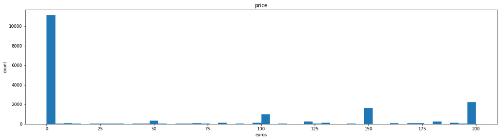

```python
fig, ax = plt.subplots(figsize=(20, 5))

ax.hist(cars.query('price <= @q1')['price'], bins=50)

ax.set_title('price')
ax.set_xlabel('euros')
ax.set_ylabel('count')

plt.show()
```

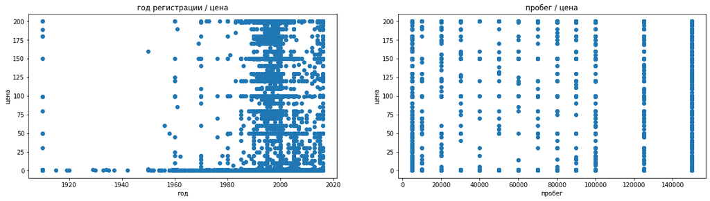

```python
fig, ax = plt.subplots(1, 2, figsize=(20, 5))

ax[0].scatter(x=cars.query('price <= @q1 & 1900 < registration_year < 2017')['registration_year'],
              y=cars.query('price <= @q1 & 1900< registration_year < 2017')['price']
             )

ax[0].set_title('год регистрации / цена')
ax[0].set_xlabel('год')
ax[0].set_ylabel('цена')

ax[1].scatter(x=cars.query('price <= @q1')['kilometer'],
              y=cars.query('price <= @q1')['price']
             )
ax[1].set_title('пробег / цена')
ax[1].set_xlabel('пробег')
ax[1].set_ylabel('цена')

plt.show()
```

Какой-то конкретной закономерности не наблюдается, а значит, что это либо ошибка, допущенная при сборе данных, либо ошибка пользователей. Все такие объекты подлежат удалению. Также, пожалуй, удалим объекты с ценами до 100 евро: на графике выше (гистограмма) виден заметный рост популярности выставляемой цены, начинающийся на 100 евро. Пожалуй, удалим все объекты с ценой менее 100 евро, списав их на флуктуации, благо что их немного.

**UPD:** удалим объекты со стоимостью менее 500 евро, поскольку все-таки 100 евро слишком неадекватно низкая цена.

```python
cars = cars.query('price >= 500')
```

Теперь разберемся с мощностью. Построенная выше гистограмма, мягко говоря, неинформативна. Поэтому попробуем сразу ограничить данные разумными пределами, скажем, значением 1000 сверху и построить график ещё раз. Выберем такое значение потому, что все машины с очень высокой вероятностью обладают мощностью до 1000 лошадиных сил, ведь даже далеко не все болиды формулы 1 по мощности доходят до такой цифры.

```python
cars = cars.query('power <= 1000')
```

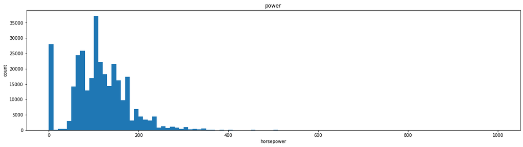

```python
fig, ax = plt.subplots(figsize=(20, 5))

ax.hist(cars['power'], bins=100)

ax.set_title('power')
ax.set_xlabel('horsepower')
ax.set_ylabel('count')

plt.show()
```

Что и следовало ожидать. Видим, что, начиная уже с 550-600 машин нет (или практически нет), что соотносится с реальностью. Другой вопрос - опять огромное количество объектов со значением признака 0. Посмотрим сначала на машины с мощностью более 500 л.с.

```python
display(cars.query('power >= 500').head(5))
print(len(cars.query('power >= 500')))
```

|  | price | vehicle_type | registration_year | gearbox | power | model | kilometer | registration_month | fuel_type | brand | repaired | date_created | postal_code |
| --- | --- | --- | --- | --- | --- | --- | --- | --- | --- | --- | --- | --- | --- |
| 4060 | 3100 | sedan | 2005 | manual | 953 | colt | 150000 | 4 | gasoline | mitsubishi | no | 2016-04-03 | 60326 |
| 6296 | 599 | small | 2002 | manual | 603 | matiz | 5000 | 11 | gasoline | chevrolet | yes | 2016-03-31 | 44379 |
| 6504 | 3000 | small | 2009 | manual | 771 | punto | 125000 | 0 | gasoline | fiat | unspecified | 2016-03-14 | 40721 |
| 6637 | 600 | small | 1996 | manual | 603 | corsa | 150000 | 8 | gasoline | opel | yes | 2016-03-31 | 70327 |
| 8057 | 500 | small | 2002 | manual | 620 | ypsilon | 150000 | 12 | gasoline | lancia | unspecified | 2016-03-15 | 55566 |

```
156
```

Сюда в основном попали маломощные машины навроде кольта или матиза, что вообще не соотносится с реальностью. Объекты с мощностью более 500 л.с. можно удалить.

```python
cars = cars.query('power <= 500')
```

Еще раз смотрим на гистограмму.

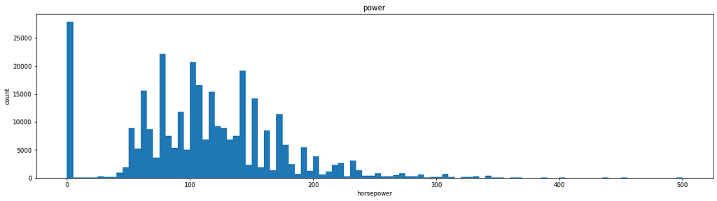

```python
fig, ax = plt.subplots(figsize=(20, 5))

ax.hist(cars['power'], bins=100)

ax.set_title('power')
ax.set_xlabel('horsepower')
ax.set_ylabel('count')

plt.show()
```

Маловато значений более 400. Интересно, что это за автомобили и придется ли снова ограничивать порог мощности?

```python
display(cars.query('power > 400').head(5))
```

|  | price | vehicle_type | registration_year | gearbox | power | model | kilometer | registration_month | fuel_type | brand | repaired | date_created | postal_code |
| --- | --- | --- | --- | --- | --- | --- | --- | --- | --- | --- | --- | --- | --- |
| 2781 | 19500 | suv | 2004 | auto | 450 | cayenne | 125000 | 12 | gasoline | porsche | no | 2016-03-16 | 38448 |
| 3289 | 16899 | wagon | 2003 | auto | 476 | e_klasse | 150000 | 9 | gasoline | mercedes_benz | no | 2016-03-10 | 44319 |
| 4681 | 13900 | sedan | 2006 | auto | 476 | e_klasse | 150000 | 5 | gasoline | mercedes_benz | no | 2016-03-25 | 52078 |
| 5319 | 10999 | wagon | 2006 | auto | 435 | other | 150000 | 12 | gasoline | audi | yes | 2016-03-27 | 52249 |
| 10354 | 18900 | wagon | 2007 | auto | 420 | 3er | 150000 | 12 | gasoline | bmw | no | 2016-03-27 | 92358 |

В целом, наименования моделей соответствуют заявленной мощности, поэтому не будем их трогать.

Теперь нужно определиться с нижним порогом. Посмотрим на гистограмму для машин с мощностью до 100 л.с.

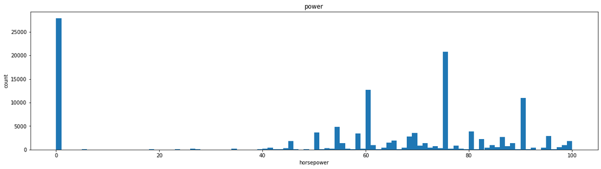

```python
fig, ax = plt.subplots(figsize=(20, 5))

ax.hist(cars.query('power <=100')['power'], bins=100)

ax.set_title('power')
ax.set_xlabel('horsepower')
ax.set_ylabel('count')

plt.show()
```

Помимо выброса на 0 видим небольшие одиночные флуктуации, которые заканчиваются в районе 30-35. Отсюда, пожалуй, ограничим мощность тридцатью лошадиными силами.

```python
cars = cars.query('power >= 30')
```

С количественными признаками разобрались, теперь переходим к датам.

##### Дата и время

Построим гистограммы для дат и годов

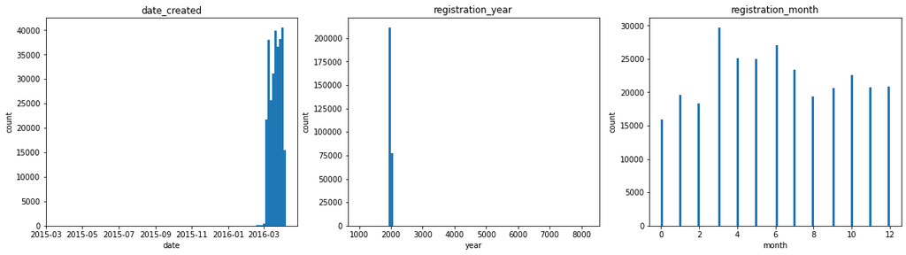

```python
fig, ax = plt.subplots(1, 3, figsize=(20, 5))
col = 0
col_names = ['date', 'year', 'month']
for i, j in zip(cars[['date_created', 'registration_year', 'registration_month']].columns, col_names):
    ax[col].hist(cars[i], bins=100)
    ax[col].set_title(i)
    ax[col].set_xlabel(j)
    ax[col].set_ylabel('count')
    col += 1
```

```python
print(cars['date_created'].max())
print(date_crawled.max())
```

```
2016-04-07 00:00:00
2016-04-07 14:36:58
```

С датами создания объявлений все в порядке: они соотносятся с датами сбора данных. С месяцами то же самое. Нам нужно разобраться с годами регистрации авто.

Сначала ограничим года регистрации относительно разумными рамками, чтобы рассмотреть график.

```python
cars = cars.query('1900 < registration_year <= 2016')
```

строим график

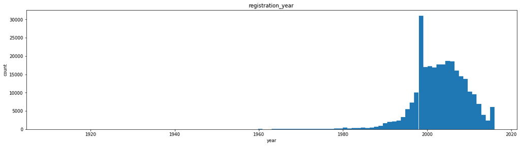

```python
fig, ax = plt.subplots(figsize=(20, 5))

ax.hist(cars['registration_year'], bins=100)
ax.set_title('registration_year')
ax.set_xlabel('year')
ax.set_ylabel('count')

plt.show()
```

Видим заметное начало левого хвоста на отметке 1960, поэтому ограничимся этим годом.

```python
cars = cars.query('registration_year >= 1960')
```

Теперь оценим количество оставшихся данных после проделанных манипуляций.

```python
print('оставшийся процент данных от изначального числа: {}%'.format(round(cars.shape[0] / cars_shape_raw[0] * 100, 2)))
print('всего удалено строк: {}'.format(cars_shape_raw[0] - cars.shape[0]))
```

```
оставшийся процент данных от изначального числа: 78.58%
всего удалено строк: 75903
```

#### Работа с признаками

Теперь поработаем с признаками. Попробуем получить месяц в виде даты, соединив месяц и год регистрации. Напоминание: мы считаем нулевой регистрации за декабрь предыдущего года. Отразим это в данных.

```python
cars.loc[cars['registration_month'] == 0, 'registration_year'] = cars.loc[cars['registration_month'] == 0, 'registration_year'] - 1
cars.loc[cars['registration_month'] == 0, 'registration_month'] = 12
```

Разложим дату создания объявления на год, месяц и число. Может пригодиться.

```python
cars['year_created'] = cars['date_created'].dt.year
cars['month_created'] = cars['date_created'].dt.month
cars['day_created'] = cars['date_created'].dt.day
```

Предобработка готова, теперь можно приступать непосредственно к подготовке данных и обучению моделей.

**P.S. ещё можно было найти страны и города с помощью геокодера, но я попытался подключить несколько разных бесплатных API, ни один из них не сработал нормально: у Яндекса нет почтовых индексов, Nominatim слишком медленно работает для такого объема данных, а Photon выдает ошибочные данные. В целом, уникальных почтовых индексов в сравнении с объемом данных весьма мало (порядка 8000), а значит они в определенной (хоть и умеренной) степени отражают непосредственное географическое положение продавца авто, которое так или иначе будет влиять на цену продажи, а значит этот признак может пригодиться.**

```python
print('количество уникальных почтовых индексов в датасете: {}'.format(cars['postal_code'].nunique()))
```

```
количество уникальных почтовых индексов в датасете: 8107
```

### Подготовка данных

Для личного удобства поменяем порядок столбцов в датасете (и выкинем данные о дате создания анкеты).

```python
cars = cars[['price',
             'power',
             'kilometer',
             'registration_year',
             'registration_month',
             'year_created',
             'month_created',
             'day_created',
             'postal_code',
             'brand',
             'model',
             'vehicle_type',
             'fuel_type',
             'gearbox',
             'repaired'
            ]]

display(cars.head(3))
print(len(cars))
```

|  | price | power | kilometer | registration_year | registration_month | year_created | month_created | day_created | postal_code | brand | model | vehicle_type | fuel_type | gearbox | repaired |
| --- | --- | --- | --- | --- | --- | --- | --- | --- | --- | --- | --- | --- | --- | --- | --- |
| 1 | 18300 | 190 | 125000 | 2011 | 5 | 2016 | 3 | 24 | 66954 | audi | unspecified | coupe | gasoline | manual | yes |
| 2 | 9800 | 163 | 125000 | 2004 | 8 | 2016 | 3 | 14 | 90480 | jeep | grand | suv | gasoline | auto | unspecified |
| 3 | 1500 | 75 | 150000 | 2001 | 6 | 2016 | 3 | 17 | 91074 | volkswagen | golf | small | gasoline | manual | no |

```
278466
```

Оценим степень корреляции признаков между собой с помощью phik-матрицы.

```python
interval_columns = ['price', 'power', 'approximate_exploitation_days']
```

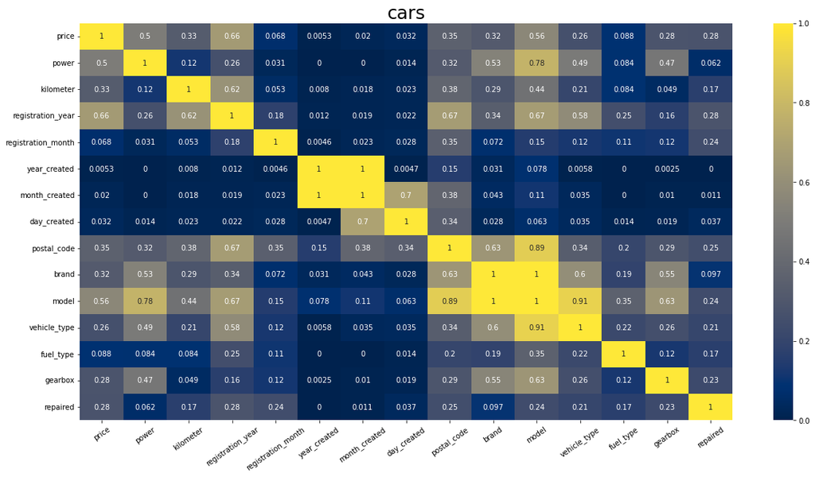

```python
fig, ax = plt.subplots(figsize=(20, 10))

sns.heatmap(cars.phik_matrix(interval_cols=interval_columns),
            annot=True,
            cmap='cividis',
           ).tick_params('x',
                         labelrotation=35)

ax.set_title('cars', fontsize=25)

plt.show()
```

Подтверждение тому, что 99.5% всех объявлений были созданы в 2016-м году:

```python
print(cars['year_created'].quantile(0.005))
```

```
2016.0
```

Посмотрим, сколько в датасете объявлений, созданных до 2016-го года.

```python
print(len(cars.query('year_created < 2016')))
```

```
24
```

Всего у нас 24 таких объявления, что буквально является каплей в море, поэтому, полагаю, можно удалить их без зазрения совести, поскольку они, хоть и совсем чуть-чуть, но только запутают модель, а наше исследование и прогноз по определению стоимости авто в принципе превращается в исследование и прогноз АКТУАЛЬНОЙ продающихся в конкретный момент/период стоимости машин =)

```python
cars = cars.query('year_created >= 2016')
```

Теперь можно удалить сами данные о времени создания анкет, так как они практически никак не коррелируют с другими признаками, включая таргет.

С корреляционным анализом покончено, поэтому теперь можно оставить только нужные признаки, проверить оставшиеся и обработанные данные на наличие полных дубликатов, которые не принесут модели практической пользы, и приступить к разделению данных на выборки.

```python
data = cars.drop(['year_created', 'month_created', 'day_created'], axis=1).copy()
```

```python
print('полных дубликатов в данных: {}'.format(data.duplicated().sum()))
```

```
полных дубликатов в данных: 18114
```

Полных дубликатов у нас более 18 тысяч. Немало! Удалим их.

```python
data = data.drop_duplicates()
```

```python
print('полных дубликатов в данных: {}'.format(data.duplicated().sum()))
```

```
полных дубликатов в данных: 0
```

Приступаем к разделению данных на выборки.

```python
X = data.drop(['price'], axis=1)
y = data['price']

X_train, X_test, y_train, y_test = train_test_split(X, y, test_size=test_size, random_state=RANDOM_STATE)
```

```python
display(data.sample(3))
```

|  | price | power | kilometer | registration_year | registration_month | postal_code | brand | model | vehicle_type | fuel_type | gearbox | repaired |
| --- | --- | --- | --- | --- | --- | --- | --- | --- | --- | --- | --- | --- |
| 283051 | 9500 | 131 | 125000 | 2008 | 12 | 90461 | opel | insignia | wagon | unspecified | manual | unspecified |
| 3571 | 6999 | 170 | 150000 | 2003 | 8 | 21031 | mercedes_benz | clk | coupe | gasoline | auto | no |
| 325030 | 1400 | 126 | 150000 | 2003 | 11 | 26871 | kia | other | bus | lpg | auto | yes |

Определим столбцы для кодирования и стандартизации. Данные в столбце с почтовыми индексами скорее являются категориальными, поэтому их не трогаем. Создадим объект ColumnTransformer для предобработки.

```python
cat_cols = ['brand',
            'model',
            'vehicle_type',
            'fuel_type',
            'gearbox',
            'repaired'
           ]

num_cols = ['power',
            'kilometer',
            'registration_year',
            'registration_month',
           ]

data_preprocessing = ColumnTransformer(

    [
        ('cat', OneHotEncoder(drop='first', handle_unknown='ignore', sparse_output=False), cat_cols),
        ('num', StandardScaler(), num_cols)
    ],
    remainder='passthrough'
)
```

Всё готово, можно приступать к обучению моделей.

## Обучение моделей

Мы попробуем обучить 5 моделей и оценим их работу относительно друг друга, а также посмотрим, будут ли они соответствовать условиям заказчика. Иными словами, наша задача заключается в подборе и оценке работы тех или иных моделей, поэтому мы не будем особо усердствовать с достижением наилучших показателей и оставим это дальнейшим исследованиям по улучшению качества и подбору параметров.

### Классические модели

Инициализируем параметры для моделей. Будем использовать три: попробуем дерево решений, случайный лес и линейную регрессию с L2-регуляризацией ввиду большой размерности признакового пространства после кодирования категориальных признаков.

```python
tree_params = [
    {
        'model__max_depth': [None] + [i for i in range(1, 7)],
        'model__max_features': np.arange(1, 30),
        'model__min_samples_leaf': np.arange(1, 30),
        'preprocessing__cat': [OrdinalEncoder(handle_unknown='use_encoded_value', unknown_value=-1, dtype='object')],
        'preprocessing__num': [StandardScaler(),
                               MinMaxScaler(),
                               RobustScaler(),
                               'passthrough'
                              ]
    }
]

ridge_params = [
    {
        'model__alpha': np.arange(0, 10, 0.5),
        'preprocessing__num': [StandardScaler(),
                               MinMaxScaler(),
                               RobustScaler(),
                               'passthrough'
                              ]
    }
]

forest_params = [

    {
        'model__n_estimators': np.arange(75, 125),
        'model__max_depth': [None] + [i for i in range(1, 7)],
        'model__max_features': np.arange(1, 30),
        'model__min_samples_leaf': np.arange(1, 30),
        'preprocessing__cat': [OrdinalEncoder(handle_unknown='use_encoded_value', unknown_value=-1, dtype='object')],
        'preprocessing__num': [StandardScaler(),
                               MinMaxScaler(),
                               RobustScaler(),
                               'passthrough'
                              ]
    }
]
```

#### Дерево решений

```python
tree_pipe = Pipeline(
    [
        ('preprocessing', data_preprocessing),
        ('model', DecisionTreeRegressor(random_state=RANDOM_STATE))
    ]
)
```

```python
%%time
rscv_tree = RandomizedSearchCV(tree_pipe,
                               param_distributions=tree_params,
                               cv=5,
                               scoring='neg_root_mean_squared_error',
                               n_iter=15,
                               n_jobs=-1,
                               verbose=1,
                               random_state=RANDOM_STATE,
                               refit=True
                              )

rscv_tree.fit(X_train, y_train)
```

```
Fitting 5 folds for each of 15 candidates, totalling 75 fits
CPU times: user 50.1 s, sys: 2.89 s, total: 53 s
Wall time: 53 s
```

```
RandomizedSearchCV(cv=5,
                   estimator=Pipeline(steps=[('preprocessing',
                                              ColumnTransformer(remainder='passthrough',
                                                                transformers=[('cat',
                                                                               OneHotEncoder(drop='first',
                                                                                             handle_unknown='ignore',
                                                                                             sparse_output=False),
                                                                               ['brand',
                                                                                'model',
                                                                                'vehicle_type',
                                                                                'fuel_type',
                                                                                'gearbox',
                                                                                'repaired']),
                                                                              ('num',
                                                                               StandardScaler(),
                                                                               ['power',
                                                                                'kilometer',
                                                                                'registration_year',
                                                                                'registration_mo...
                                         'model__min_samples_leaf': array([ 1,  2,  3,  4,  5,  6,  7,  8,  9, 10, 11, 12, 13, 14, 15, 16, 17,
       18, 19, 20, 21, 22, 23, 24, 25, 26, 27, 28, 29]),
                                         'preprocessing__cat': [OrdinalEncoder(dtype='object',
                                                                               handle_unknown='use_encoded_value',
                                                                               unknown_value=-1)],
                                         'preprocessing__num': [StandardScaler(),
                                                                MinMaxScaler(),
                                                                RobustScaler(),
                                                                'passthrough']}],
                   random_state=17, scoring='neg_root_mean_squared_error',
                   verbose=1)
```

```python
tree_rmse = np.abs(rscv_tree.best_score_)

tree = rscv_tree.best_estimator_

tree_start = tm.time()
tree.fit(X_train, y_train)
tree_fit_time = tm.time() - tree_start

tree_start = tm.time()
tree_pred = tree.predict(X_train)
tree_pred_time = tm.time() - tree_start
```

#### Линейная регрессия

```python
ridge_rmse = np.abs(rscv_ridge.best_score_)

ridge = rscv_ridge.best_estimator_

ridge_start = tm.time()
ridge.fit(X_train, y_train)
ridge_fit_time = tm.time() - ridge_start

ridge_start = tm.time()
ridge_pred = ridge.predict(X_train)
ridge_pred_time = tm.time() - ridge_start
```

[output not shown]

#### Случайный лес

```python
forest_rmse = np.abs(rscv_forest.best_score_)

forest = rscv_forest.best_estimator_

forest_start = tm.time()
forest.fit(X_train, y_train)
forest_fit_time = tm.time() - forest_start

forest_start = tm.time()
forest_pred = forest.predict(X_train)
forest_pred_time = tm.time() - forest_start
```

[output not shown]

### Алгоритмы градиентного бустинга

#### LightGBM

```python
lgb_rmse = np.abs(grid_lgb.best_score_)

lgb = grid_lgb.best_estimator_

lgb_start = tm.time()
lgb.fit(X_train, y_train)
lgb_fit_time = tm.time() - lgb_start

lgb_start = tm.time()
lgb_pred = lgb.predict(X_train)
lgb_pred_time = tm.time() - lgb_start
```

[output not shown]

#### Catboost

```python
pd.DataFrame.iteritems = pd.DataFrame.items
```

[output not shown]

Итак, наши модели готовы, теперь осталось проанализировать и оценить их работу.

## Анализ моделей

**Напоминание: заказчик попросил нас построить модель, которая будет не только хорошо предсказывать стоимость автомобилей, но и просил учитывать скорость обучения и предсказания, тем не менее не уточнив временные рамки, поэтому время обучения и работы будем оценивать относительно. Основной критерий успеха - RMSE < 2500.**

### Выбор лучшей модели

Для начала соберем модели и их показатели в датафрейм.

```python
model_performance = pd.DataFrame(
    {
        'model': ['DecisionTreeRegressor', 'LinearRegression', 'RandomForestRegressor', 'LightGBM', 'Catboost'],
        'valid_rmse': [tree_rmse, ridge_rmse, forest_rmse, lgb_rmse, cb_rmse],
        'train_fit_time_sec': [tree_fit_time, ridge_fit_time, forest_fit_time, lgb_fit_time, cb_fit_time],
        'train_pred_time_sec': [tree_pred_time, ridge_pred_time, forest_pred_time, lgb_pred_time, cb_pred_time]
    }
)

display(model_performance)
```

|  | model | valid_rmse | train_fit_time_sec | train_pred_time_sec |
| --- | --- | --- | --- | --- |
| 0 | DecisionTreeRegressor | 1864.832510 | 1.485480 | 0.404622 |
| 1 | LinearRegression | 2594.404052 | 2.968088 | 1.302628 |
| 2 | RandomForestRegressor | 1766.279283 | 61.410009 | 3.460760 |
| 3 | LightGBM | 1688.297489 | 6.372276 | 2.194462 |
| 4 | Catboost | 1602.833556 | 231.578289 | 1.568987 |

**Вывод:** В плане качества лучше всего себя показали модели градиентного бустинга, а в плане скорости обучения и предсказания - классические алгоритмы, в частности, дерево решений. Далее попробуем дать общую оценку работе каждой модели.

Поскольку заказчик не уточнил конкретное время работы и обучения нужной ему модели, мы вынуждены ориентироваться преимущественно на качество предсказаний. Нам нужно сложить общую оценку таким образом, чтобы быстрые модели с плохими предсказаниями не могли превзойти модели с хорошими предсказаниями, но плохими или средними временными показателями. Введем относительную приоритизированную оценку работы модели, которая работает следующим образом: в зависимости от приоритета (ранга) того или иного показателя он будет вносить разный вклад в итоговую оценку, где оценки рассчитываются исходя из нормализованных значений (нормализация оценок также позволит оценить степень превосходства одной модели над другой) показателей. Вот формула итоговой оценки для i-той модели:

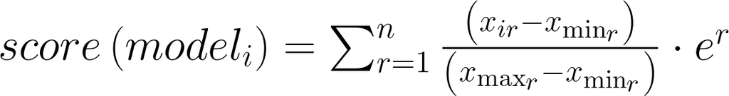

где:

- r - важность (ранг) показателя;
- n - количество показателей;
- i - индекс модели;
- xir - значение показателя модели

Так как все показатели у нас инвертированные (чем меньше их значение, тем лучше), итоговая формула расчета будет выглядеть так:

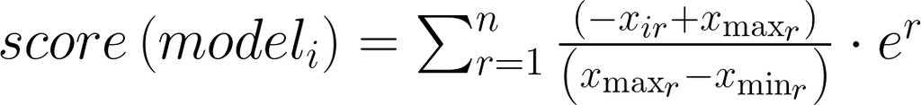

Попробуем применить формулу к показателям модели и посмотрим, что получилось.

Порядок важности оценок или показателей (по убыванию) определим следующим образом:

1. Оценка RMSE модели на валидационных данных - качество первостепенно: мы ориентируемся в первую очередь на эту метрику;
2. Оценка времени предсказания модели - второй по важности показатель, который определяет скорость предсказания модели, что критически важно в непосредственной работе;
3. Оценка времени обучения модели на тренировочном датасете - последний по важности показатель из имеющихся, поскольку модель обычно обучается единожды и далее запускается в работу, постоянно делая предсказания, поэтому время работы будет важнее времени обучения. Тем не менее, мы всё равно будем учитывать этот показатель, ведь характер данных всегда может измениться со временем, и модель так или иначе придется переобучить, иногда срочно и на больших, чем мы имеем сейчас, данных.

Смотрим на итоговую таблицу:

```python
scores = rel_prioritized_inversed_neg_scoring(model_performance[['model',
                                                                 'valid_rmse',
                                                                 'train_pred_time_sec',
                                                                 'train_fit_time_sec'
                                                                ]],
                                              'model'
                                             )
display(scores)
```

|  | model | valid_rmse | train_pred_time_sec | train_fit_time_sec | valid_rmse_score^3 | train_pred_time_sec_score^2 | train_fit_time_sec_score^1 | score_total |
| --- | --- | --- | --- | --- | --- | --- | --- | --- |
| 0 | DecisionTreeRegressor | 1864.832510 | 0.404622 | 1.485480 | 14.78 | 7.39 | 2.72 | 24.89 |
| 1 | Catboost | 1602.833556 | 1.568987 | 231.578289 | 20.09 | 4.57 | 0.00 | 24.66 |
| 2 | LightGBM | 1688.297489 | 2.194462 | 6.372276 | 18.35 | 3.06 | 2.66 | 24.07 |
| 3 | RandomForestRegressor | 1766.279283 | 3.460760 | 61.410009 | 16.77 | 0.00 | 2.01 | 18.78 |
| 4 | LinearRegression | 2594.404052 | 1.302628 | 2.968088 | 0.00 | 5.22 | 2.70 | 7.92 |

**Вывод:** в итоге нам приходится выбирать между скоростью и качеством. Одна модель имеет превосходные показатели быстродействия, но уступает в значении ключевой метрики лучшему результату на +-15% в абсолютном и на +-26% в оценочном выражении, вторая имеет наивысшую оценку метрики, но в сумме выдает посредственные показатели быстродействия. Учитывая все это, мы выбираем модель LightGBM. По всем показателям относительно всех остальных моделей она имеет плюс-минус среднюю оценку, которую можно назвать оптимальной или сбалансированной. Плюс общий зачет показывает, что по сумме оценок она отстоит не так далеко от обеих топ-2 моделей с перекосом в одну из сторон (качество/быстродействие) каждая и находится с ними в одной категории, что является для нас идеальным вариантом.

Итог: мы выбрали модель LightGBM, и она пойдет в работу. Оценим качество её работы на тестовой выборке, а также проверим на адекватность.

### Проверка на адекватность и анализ качества работы выбранной модели

Сначала проверим выбранную модель на адекватность. Для этого подберем параметры и найдем лучший DummyRegressor, который всегда предсказывает константу.

```python
dummy_pipe = Pipeline(
    [
        ('preprocessing', data_preprocessing),
        ('models', DummyRegressor())
    ]
)

dummy_params = [
    {
        'models': [DummyRegressor()],
        'models__strategy': ['mean',
                             'median'
                            ],
        'preprocessing__num': [StandardScaler(),
                               MinMaxScaler(),
                               RobustScaler(),
                               'passthrough'
                              ]
    },
    {
        'models': [DummyRegressor()],
        'models__strategy': ['quantile'],
        'models__quantile': np.arange(0, 1, 0.05),
        'preprocessing__num': [StandardScaler(),
                               MinMaxScaler(),
                               RobustScaler(),
                               'passthrough'
                              ]
    },
]

dummy_grid = GridSearchCV(dummy_pipe,
                          param_grid=dummy_params,
                          cv=3,
                          scoring='neg_root_mean_squared_error',
                          n_jobs=-1,
                          verbose=2
                         )

dummy_grid.fit(X_train, y_train)
```

[output not shown]

[output cut: 210 more lines]

[output not shown]

```
GridSearchCV(cv=3,
             estimator=Pipeline(steps=[('preprocessing',
                                        ColumnTransformer(remainder='passthrough',
                                                          transformers=[('cat',
                                                                         OneHotEncoder(drop='first',
                                                                                       handle_unknown='ignore',
                                                                                       sparse_output=False),
                                                                         ['brand',
                                                                          'model',
                                                                          'vehicle_type',
                                                                          'fuel_type',
                                                                          'gearbox',
                                                                          'repaired']),
                                                                        ('num',
                                                                         StandardScaler(),
                                                                         ['power',
                                                                          'kilometer',
                                                                          'registration_year',
                                                                          'registration_month'])...
                                                 MinMaxScaler(), RobustScaler(),
                                                 'passthrough']},
                         {'models': [DummyRegressor()],
                          'models__quantile': array([0.  , 0.05, 0.1 , 0.15, 0.2 , 0.25, 0.3 , 0.35, 0.4 , 0.45, 0.5 ,
       0.55, 0.6 , 0.65, 0.7 , 0.75, 0.8 , 0.85, 0.9 , 0.95]),
                          'models__strategy': ['quantile'],
                          'preprocessing__num': [StandardScaler(),
                                                 MinMaxScaler(), RobustScaler(),
                                                 'passthrough']}],
             scoring='neg_root_mean_squared_error', verbose=2)
```

```python
print(f'Лучшее значение RMSE при кросс_валидации: {round(np.abs(dummy_grid.best_score_), 2)}')
print(f'Лучшая dummy-модель и её параметры: {dummy_grid.best_params_}')
```

```
Лучшее значение RMSE при кросс_валидации: 4594.01
Лучшая dummy-модель и её параметры: {'models': DummyRegressor(), 'models__strategy': 'mean', 'preprocessing__num': StandardScaler()}
```

```python
dummy_pred_train = dummy_grid.best_estimator_.predict(X_train)
dummy_pred_test = dummy_grid.best_estimator_.predict(X_test)

print(f" RMSE лучшей dummy-модели на тренировочных данных {round(rmse(y_train, dummy_pred_train), 2)}")
print(f" RMSE лучшей dummy-модели на тестовых данных {round(rmse(y_test, dummy_pred_test), 2)}")
```

```
 RMSE лучшей dummy-модели на тренировочных данных 4593.98
 RMSE лучшей dummy-модели на тестовых данных 4609.99
```

Теперь сравним полученные метрики с метриками нашей LightGBM-модели.

```python
lgb_train_pred = lgb.predict(X_train)
lgb_test_pred = lgb.predict(X_test)

print(f" RMSE LightGBM-модели на тренировочных данных {round(rmse(y_train, lgb_train_pred), 2)}")
print(f" RMSE LightGBM-модели на тестовых данных {round(rmse(y_test, lgb_test_pred), 2)}")
```

```
 RMSE LightGBM-модели на тренировочных данных 1653.25
 RMSE LightGBM-модели на тестовых данных 1684.51
```

Наша модель показала в несколько раз лучший результат, а значит работает отлично.

Теперь проанализируем остатки предсказаний модели на тестовых данных.

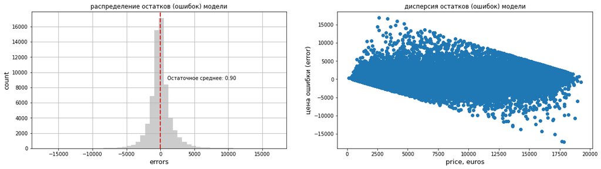

```python
residuals_analysis_plotter(y_test, lgb_test_pred, figsize=(20, 5), xlabel='price, euros', mean_text_x_coef_degree=10, mean_text_y_coef=2, bins=50, suptitle=None, scatter_grid=False)
```

**ИТОГ: исследование проведено, условия заказчика выполнены, и итоговая модель готова к работе.**